# Exploratory Data Analyses: VCR LTER

Sean Hardison

## Introduction

The purpose of this document is to familiarize myself with the types of data being collected as part of the [Virginia Coast Reserve Long-Term Ecological Research](https://www.vcrlter.virginia.edu/) program.

## Study Area

[figure not shown]

## Small Mammal Trapping

**Title**: Hog Island VA Small-Mammal Trapping, 1989-2016

**Citation**: Porter, J. and R. Dueser. 2016. Hog Island VA Small-Mammal Trapping 1989-2016. Virginia Coast Reserve Long-Term Ecological Research Project Data Publication knb-lter-vcr.49.34 (doi:doi:10.6073/pasta/a6745259025acbd2438f0a975f404978 ).

**Abstract**: "This dataset contains information on long-term small mammal trapping on the Virginia Coast Reserve LTER.

Four transects on Hog Island are included in the data, each of which was trapped at least twice each year, typically in the spring and autumn (note: Transect T2 was not trapped every year).

Along each transect Sherman Live Traps were placed every 12.5 m along the transect, with an alternating offset of 2.5 m (to remove traps from the path running down the transect). This leaves a total inter-trap distance of 15 m.

Traps were baited with peanut butter wrapped in waxed paper and were run sequentially for at least 3 nights in a row.

Traps in areas that would experience tidal flooding were placed on styrofoam plastic platforms to provide flotation during high tides.

Captured animals were individually tagged with numbered fingerling fish tags placed in the right ear, inspected for sex and sexual characteristics, weighed with a spring scale to the nearest gram and released at the point of capture."

**Contacts**: jhp7e@virginia.edu

**Notes**:

### Processing

```r
d <- read.csv(file.path(data.dir, "SmallMammalTrapping.csv"), stringsAsFactors = F) %>%
  mutate(SPECIES, SPECIES = plyr::mapvalues(SPECIES, from = c(1,2,3,4,5,6,7,8),
                                            to = c("Cryptotis parva (least shrew)",
                                                   "Mus musculus (house mouse)",
                                                   "Microtus pennsylvanicus (meadow vole)",
                                                   "Oryzomys palustris (rice rat)",
                                                   "Peromyscus leucopus (white-footed mouse)",
                                                   "Rattus norvegicus (Norway rat)",
                                                   "Zapus hudsonius (meadow jumping mouse)",
                                                   "Blarina brevicauda (short-tailed shrew)"))) %>%
  filter(SEASON == "Autumn ", SPECIES != 9, SPECIES != 0) %>% #select season and discard NAs. Summer has low temporal coverage (1989 and 1990 only)
  mutate(YEAR = ifelse(YEAR %in% c(0:9), paste0(200,YEAR),
                           ifelse(YEAR %in% c(10:16), paste0(20,YEAR), #Fix year column
                                  paste0(19,YEAR)))) %>%
  tidyr::unite(., Time, c("DAY","MONTH","YEAR"), sep = "-") %>%
  mutate(Time = dmy(Time)) %>% #combine into date column and format
  distinct(., TAG, .keep_all = TRUE) %>% #%>% #select all distinct individuals (no repeat offenders)
  filter(TRAPDAY <= 3, SITE != "T2 ") #All sites had at least 3 trap days, so this is the minimum. Sampling at site T2 is not consistent with other sites, so is excluded here


#Question: Have fall species abundances changed through time?

#For plotting
all_obs <- d %>% mutate(Year = year(Time)) %>%
  dplyr::select(SPECIES, Year, SITE) %>%
  group_by(SPECIES, Year, SITE) %>%
  dplyr::summarise(n = n()) %>% #count incidence of species
  dplyr::rename(Species = SPECIES) %>%
  dplyr::summarise(mean = mean(n),
                   SE = sd(n),
                   sum = sum(n)) %>%
  mutate(lower = mean - SE,
         upper = mean + SE)

#For a linear-mixed effects model. The random effect here is SITE, which we assume to be a representative subset of the population. This is a repeated measures design.
lme_test <-  d %>% mutate(Year = year(Time)) %>%
  dplyr::select(SPECIES, Year, SITE) %>%
  group_by(SPECIES, Year, SITE) %>%
  dplyr::summarise(n = n()) %>%
  dplyr::rename(Species = SPECIES)

lme_test$SITE <- str_replace(lme_test$SITE, " ", "")


#Has the prevalence of the house mouse changed through time? ----------------------------------------
mus_musculus <- lme_test %>% filter(Species == "Mus musculus (house mouse)") %>%
  ungroup() %>%
  mutate(Year, Year = plyr::mapvalues(Year, from = c(1991:2006,2008:2016),
                                      c(1:16,18:26)))

#Does an AR1 error structure give the model a better fit?
mus_ar1 <- lme(n ~ Year, random= ~1|SITE, data = mus_musculus, correlation = corAR1())
mus_null <- lme(n ~ Year, ~1|SITE, data = mus_musculus)

#It's slightly better, but not by much (p < 0.05). Observations are correlated with previous year
# anova(update(mus_ar1, method = "ML"),
#       update(mus_null, method = "ML"))

#Is the model with Year specified as a fixed effect better than the null model?
mus_mod <- lme(n ~ Year, random= ~1|SITE, data = mus_musculus, correlation = corAR1())
mus_null <- lme(n ~ 1, ~1|SITE, data = mus_musculus, correlation = corAR1())

#Line fit
Time2 <- 1:26
mus_pred <- predict(mus_mod, level = 0, list(Year = Time2)) #m*x + b, averaged slope across levels of SITE
mus_pred <- data.frame(pred = mus_pred,
                   Time = 1991:2016)

#----------------------------------------------------------------------------------------------------

#Has the prevalence of the rice rat changed through time?
oryzomys_palustris <- lme_test %>% filter(Species == "Oryzomys palustris (rice rat)") %>%
  ungroup() %>%
  mutate(Year, Year = plyr::mapvalues(Year, from = c(1991:2006,2008:2016),
                                      c(1:16,18:26)))

#Build models, specifying AR1 error strucure and SITE as a random effect
palus_mod <- lme(n ~ Year, ~1|SITE, data = oryzomys_palustris, correlation = corAR1())
palus_null <- lme(n ~ 1, ~1|SITE, data = oryzomys_palustris, correlation = corAR1())

#Is the model considering time as a fixed effect any better than the null model?
# anova(update(palus_mod, method = "ML"),
#       update(palus_null, method = "ML"))

#Line fit
palus_pred <- predict(palus_mod, level = 0, list(Year = Time2))
palus_pred <- data.frame(pred = palus_pred,
                   Time = 1991:2016)
```

### Visualization

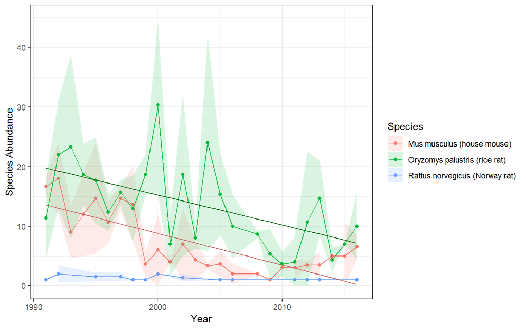

Mean abundance of unique house mice, rice rats, and Norway rats across sampling sites and through time at Hog Island, VA. Lines show linear mixed-effects model fits, and shaded regions show +/- 1 sample SD.

## Seagrass Density

**Title**: Density of Seagrass in Hog Island Bay and South Bay, VA 2007-2017

**Citation**: McGlathery, K. 2017. Density of Seagrass in Hog Island Bay and South Bay, VA 2007-2017. Virginia Coast Reserve Long-Term Ecological Research Project Data Publication knb-lter-vcr.181.18 (doi:doi:10.6073/pasta/5a6ea442cf59cabb3112bb634a968ae5 ).

**Abstract**: “This dataset contains measurements of seagrass shoot density in restored *Z. marina* meadows in the Virginia coastal bays. Measurements were made annually in June-July at plots in Hog Island Bay and South Bay, VA. GPS locations of sampling plots are available in the companion data set VCR11180.”

**Contacts**: kjm4k@virginia.edu

**Notes**: “In 2017, 12 new monitoring sites were added to the protocol: 6 in South Bay (SB) and 6 in Hog Island Bay (HI). These new plots are from areas of natural seagrass expansion, not from seeded plots. The variable”Age" is the years since seagrass first appeared in the new plots. The new plots were sampled using the protocol for 1 acre plots."

### Processing

```r
#Shoot density
sdens <- read.csv(file.path(data.dir,"ShootDens_2007-2017.csv"))

#Across all sites
shoots <- sdens %>%
  mutate(Location = ifelse(str_detect(PLOT, "HI"),
                       "Hog Island", ifelse(str_detect(PLOT, "SB"),
                                    "South Bay", "other"))) %>%
  mutate(Location = factor(Location, levels = c("Hog Island","South Bay")))

#Annual density at grouped sampling sites
annual_by_group <- shoots %>% group_by(Location, SAMPYR) %>%
  dplyr::summarise(dens = mean(SHOOTS),
                   SD = sd(SHOOTS, na.rm = T)) %>%
  mutate(lower = dens - SD, upper = dens + SD) %>%
  as.data.frame()

#Area averaged
annual_sdens <- shoots %>% group_by(SAMPYR) %>%
  dplyr::summarise(dens = mean(SHOOTS),
                   SD = sd(SHOOTS, na.rm = T)) %>%
  mutate(lower = dens - SD, upper = dens + SD) %>%
  dplyr::mutate(Location = "Area averaged") %>%
  as.data.frame()

#Bind all
annual_by_group <- rbind(annual_by_group,annual_sdens) %>%
 mutate(Location = factor(Location, levels = c("Hog Island","South Bay","Area averaged")))
```

### Visualization

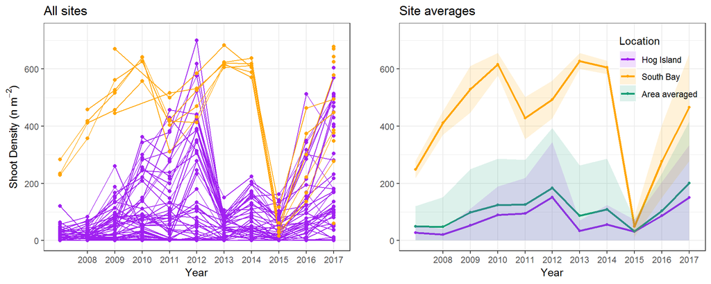

Figures show shoot densities through time at sites at South Bay, VA (orange) and Hog Island, VA (purple). Shaded regions show +/- 1 sample SD.

## Benthic Chlorophyll

**Title**: Benthic Chlorophyll of Seagrass Sediment in Hog Island Bay and South Bay, VA 2008-2017

**Citation**: McGlathery, K. 2017. Benthic Chlorophyll of Seagrass Sediment in Hog Island Bay and South Bay, VA 2008-2017. Virginia Coast Reserve Long-Term Ecological Research Project Data Publication knb-lter-vcr.182.19 (doi:doi:10.6073/pasta/60a228352daa61d85bc7a1b37f0ec5a4 ).

**Abstract**: “This data set contains measurements of benthic chlorophyll content in surface sediments in restored *Z. marina* plots in the Virginia coastal bays. Samples were collected annually during June-July at restored seagrass plots and adjacent bare sediment plots. GPS locations of sampling plots are available in the companion data set VCR11180.”

**Contacts**: kjm4k@virginia.edu

**Notes**: “In 2017, 12 new monitoring sites were added to the protocol: 6 in South Bay (SB) and 6 in Hog Island Bay (HI). These new plots are from areas of natural seagrass expansion, not from seeded plots. The variable”Age" is the years since seagrass first appeared in the new plots. The new plots were sampled using the protocol for 1 acre plots."

### Processing

```r
#Benthic chlorophyll
bchl <- read.csv(file.path(data.dir,"BenthChl_2007-2017.csv"))

#Across all sites
chl <- bchl  %>%
  mutate(Location = ifelse(str_detect(PLOT, "HI"),
                       "Hog Island", ifelse(str_detect(PLOT, "SB"),
                                    "South Bay", "other"))) %>%
  mutate(Location = factor(Location, levels = c("Hog Island","South Bay")))

#Annual chl at grouped sampling sites
annual_by_group <- chl %>% group_by(Location, SAMPYR) %>%
  dplyr::summarise(chl = mean(BEN_CHL),
                   SD = sd(BEN_CHL, na.rm = T)) %>%
  mutate(lower = chl - SD, upper = chl + SD) %>%
  as.data.frame()

#Area averaged
annual_chl <- chl %>% group_by(SAMPYR) %>%
  dplyr::summarise(chl = mean(BEN_CHL),
                   SD = sd(BEN_CHL, na.rm = T)) %>%
  mutate(lower = chl - SD, upper = chl + SD) %>%
  dplyr::mutate(Location = "Area averaged") %>%
  as.data.frame()

#Bind all
annual_by_group <- rbind(annual_by_group,annual_chl) %>%
 mutate(Location = factor(Location, levels = c("Hog Island","South Bay","Area averaged")))
```

### Visualization

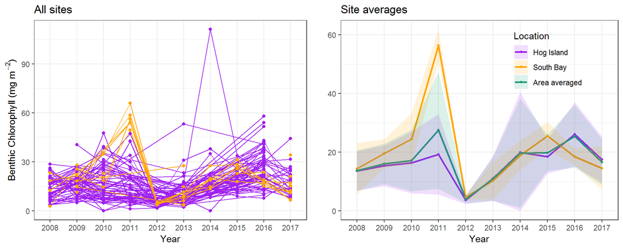

Figures show benthic chlorophyll in restored seagrass sediments through time at sites at South Bay, VA (orange) and Hog Island, VA (purple). Shaded regions show +/- 1 sample SD. Note the change in y-axis scale between plots.

## Meteorology

**Title**: Hourly Meteorological Data for the Virginia Coast Reserve LTER 1989-present

**Citation**: Porter, J., D. Krovetz, W. Nuttle and J. Spitler. 2018. Hourly Meteorological Data for the Virginia Coast Reserve LTER 1989-present. Virginia Coast Reserve Long-Term Ecological Research Project Data Publication knb-lter-vcr.25.37 (doi:doi:10.6073/pasta/c87febba463a3ac63a64bdb484a197ce ).

**Abstract**: “Data from VCR/LTER meteorological stations is listed in comma-separated-value (CSV) files by year. A combined file for all years is also available, sorted by station, date and time, however, unlike the annual files, this combined file is too large for most spreadsheets to handle. A compressed copy of all the .CSV files is included in a single .ZIP file for users who wish to conveniently download a copy of all the data.”

**Contacts**: jhp7e@virginia.edu

**Notes**: Meteorological data from four sampling sites:

| ID | Station |
| --- | --- |
| HOGMET | Hog Island meteorological Station |
| OYSMET | Oyster Meteorological Station |
| OYSMET0 | Old Location for Oyster Met. Station (1989-1995) |
| PHCKMET | Phillips Creek Meteorological Station |

Time series figures below were produced by averaging site data across years. It would appear that there are discrepancies between sites listed in metadata and sites in the data set.

### Processing

```r
load(file.path(data.dir,"met_hourly_1989-2018.Rdata"))

avg <- wq %>%
  mutate(PAR = ifelse(as.numeric(PAR) < 0,NA,as.numeric(PAR))) %>%
   group_by(year, STATION) %>%
  dplyr::summarise(Temperature = mean(AVG_T, na.rm = T),
                    `Relative Humidity` = mean(AVG_RH, na.rm = T),
                    `Wind Speed` = mean(AVG_WS, na.rm = T),
                   `Wind Angle` = mean(as.numeric(AVG_WANG), na.rm = T),
                    `Soil Temperature` = mean(SOIL_T, na.rm = T),
                   Precipitation = mean(as.numeric(PPT), na.rm = T),
                  `Solar Radiation` = mean(as.numeric(RS), na.rm = T),
                  `PAR` = mean(as.numeric(PAR), na.rm = T)) %>%
  filter(`Wind Speed` < 100) %>%
  dplyr::rename(Year = year) %>%
  mutate(STATION = factor(STATION, levels = c(unique(.$STATION))))
```

### Plotting

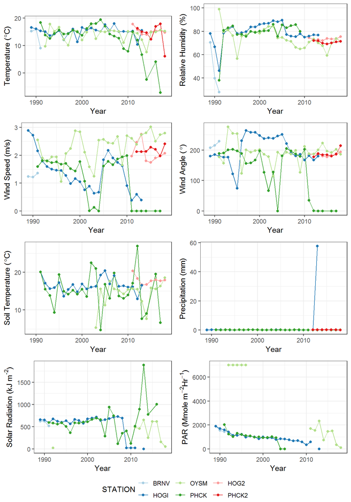

## Water Quality

**Title**: Water Quality Sampling - integrated measurements for the Virginia Coast, 1992-2018

**Citation**: McGlathery, K. and R. Christian. 2018. Water Quality Sampling - integrated measurements for the Virginia Coast, 1992-2018. Virginia Coast Reserve Long-Term Ecological Research Project Data Publication knb-lter-vcr.247.10 (doi:doi:10.6073/pasta/b650b236f092e0fdee0d5d8ccf521cb3 ).

**Abstract**: “This dataset contains information about the aquatic environment along two transects that run from inlet to the mainland shore on the southern part of the Delmarva Peninsula since 1992. It has a large number of columns (111) that integrate information on water column and benthic measurements. Frequency of sampling varies from monthly to quarterly, and not all variables are necessarily measured on the same dates. However, all the data from a given date and location appears on a single line of the dataset.”

**Contacts**: jhp7e@virginia.edu

**Notes**: A linear interpolation step was performed when missing values comprised < 20% of the length of the series. Interpolated values are shown in red in the figures below.

### Processing

```r
load(file = file.path(data.dir, "IntegratedWaterQual_1992-2018.Rdata"))

missing_years <- data.frame(Year = 1992:2017)

d <- wq %>%
  dplyr::select(station, measureDate,chlor_a, tss, nh3, po4, nox, no2, din, pom) %>%
  mutate(Time = mdy(measureDate)) %>%
  mutate(Month = month(Time), Year = year(Time)) %>%
  filter(Month %in% c(6,7,8,9)) %>%
    group_by(Year) %>%
  dplyr::summarise(Chlorophyll = mean(chlor_a, na.rm = T),
                   TSS = mean(tss, na.rm = T),
                   NH3 = mean(nh3, na.rm = T),
                   PO4 = mean(po4, na.rm = T),
                   NOX = mean(nox, na.rm = T),
                   DIN = mean(din, na.rm = T)) %>%
  full_join(missing_years,., by = "Year") %>% #bind in missing years
  tidyr::gather(., Var, Value, Chlorophyll:DIN) %>%

  mutate(interp = NA)

#Interpolate missing values if reasonable (20% missing is probably a stretch) to do so
dna <- NULL
for (i in 1:length(unique(d$Var))){

  sub <- d[d$Var == unique(d$Var)[i],] #subset
  missing <- which(is.na(sub$Value)) #Get index of missing values

  if (1 - nrow(sub[is.na(sub$Value),])/nrow(sub) > .8){  #If 80% of observations are present, then interpolate
    sub$Value <- approx(sub$Year, sub$Value, n  = nrow(sub))$y
  }

  sub[missing,]$interp <- TRUE #mark interpolated data

  assign('dna',rbind(dna,sub))

}
```

### Visualization

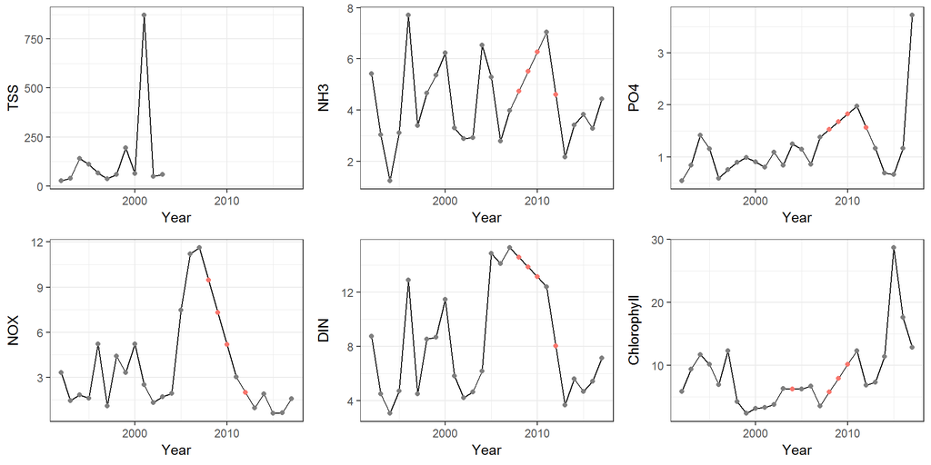